# EDM transcriptional network analysis

Pao, Deyle, Ye, et al.

9/22/2020

This file takes several inputs and produces several outputs. The outputs cover all necessary files for reproducing the Main Text and Supplementary Text figures and tables via “figures_and_tables.Rmd”.

## Pre-amble

Load other required packages.

```r
library("rEDM")
library("tidyverse")
library("gridExtra")
```

```r
library("grid")
library("ggraph")
library("igraph")
```

Finally we want to source the `help_functions.R` script included in the repository. This script contains several functions to reproduce plots and pieces of plots from the Main Text from the analysis performed in this Markdown.

```r
source('help_functions.R')
```

# Read in raw data

The raw data for Yeast are formatted as follows:

```
- row 1 = index for which dataset
- row 2 = time ordering within each dataset
- row 3 = sample ID
- col 1 = row name
- if input has m rows and n cols, then data values occur for rows 4:m, cols 2:n
```

We read in and apply formatting to aid understanding. This includes relabelling the datasets by the batch and strain. Batch “whi5” refers to Batch 1 in the main text, where the experimental manipulation targeted WHI5 through overexpression; batch “yhp1” refers to Batch 2 in the main text, where experimental manipulation targeted YHP1 through knockout.

```r
options("stringsAsFactors" = FALSE)

read_raw_data <- function(data_file = "CorrectedYeast-UQnormalized-genes_TPM.txt",
                          out_file = "data/gene_data_TPM.Rdata")
{


    raw_data <- read.table(data_file)
    gene_names <- raw_data[4:NROW(raw_data), 1]
    gene_names <- gsub("[\\(\\)-]", ".", gene_names)
    raw_data <- raw_data[, -1]

    dataset_idx <- as.factor(t(raw_data[1, ]))
    # levels(dataset_idx) <- c("whi5_wt", "whi5_exp", "yhp1_wt", "yhp1_exp")
    levels(dataset_idx) <- c("WT1", "ExM1", "WT2", "ExM2")
    dataset_time <- as.numeric(t(raw_data[2, ])) + 1
    raw_data <- raw_data[c(-1, -2, -3), ]

    raw_data <- t(raw_data)
    class(raw_data) <- "numeric"
    gene_data <- data.frame(raw_data)
    names(gene_data) <- gene_names
    gene_data <- data.frame(dataset = dataset_idx,
                            time = dataset_time,
                            gene_data)
    save(gene_data, file = out_file)
}
```

The raw data from the Mouse MEF are formatted differently, thus define a separate function.

```r
read_raw_mouse <- function(data_file_1 = "Main-genes_MEF_original_96_RAWTMP.csv",
                           data_file_2 = "Main-genes_MEF_CF1.csv",
                           data_file_3 = "mouse_data_TMP_E2FVP16.csv",
                           out_file = "Data/mouse_data_TMP.Rdata")
{
    # read in raw data from tab-delimited files
    #   row 1 = time ordering within each dataset
    #   row 2...  = samples
    #   col 1 = row (gene) name
    #   if input has m rows and n cols, then
    #     data values occur for rows 4:m, cols 2:n

    raw_data_1 <- read.table(data_file_1,sep=",")
    raw_data_2 <- read.table(data_file_2,sep=",")
    raw_data_3 <- read.table(data_file_3,sep=",")
    raw_data <- full_join(raw_data_1,raw_data_2,by="V1")
    raw_data <- full_join(raw_data,raw_data_3,by="V1")
    gene_names <- raw_data[2:NROW(raw_data), 1]
    gene_names <- gsub("ENSMUSG00000", "MUSG", gene_names)
    raw_data <- raw_data[, -1]

    # time is stored in a string describing the sample
    # Ex: c1_-1h_mm10_gencode-m5
    get_hr <- function(s) as.numeric(regmatches(s,regexec("_(.+)h",s))[[1]][2])
    dataset_time <- sapply(t(raw_data[1, ]),get_hr,USE.NAMES = FALSE)
    raw_data <- raw_data[-1, ]

    raw_data <- t(raw_data)
    class(raw_data) <- "numeric"
    gene_block_mouse_joined <- data.frame(raw_data)

    I_nonzero <- gene_block_mouse_joined %>% summarize_all(funs(sd(.,na.rm=TRUE))) %>% `>`(0) %>% which()
    # I_nonzero <- gene_block_mouse_joined %>% summarize_all(list(~ all(duplicated(. )[-1L])) ) %>% which()
    gene_block_mouse_joined <- gene_block_mouse_joined[,I_nonzero]
    names(gene_block_mouse_joined) <- gene_names[I_nonzero]

    gene_block_mouse_joined <- data.frame(dataset = "MEF_joined",
                            time = dataset_time,
                            gene_block_mouse_joined) %>%
      filter(time == floor(time))

    save(gene_block_mouse_joined, file = out_file)
}
```

### Read in and save datasets

```r
out_file <- "Data/gene_data_TPM_corrected.Rdata"
if(!file.exists(out_file)){
  read_raw_data(data_file = "CorrectedYeast-UQnormalized-genes_TPM.txt",
                out_file = out_file)
}else{
  load("Data/gene_data_TPM_corrected.Rdata")
}

out_file <- "Data/mouse_data_TMP.Rdata"
if(!file.exists(out_file)){
  read_raw_mouse(data_file_1 = "Main-genes_MEF_original_96_RAWTMP.csv",
                 data_file_2 = "Main-genes_MEF_CF1.csv",
                 data_file_3 = "mouse_data_TMP_E2FVP16.csv",
                 out_file = "Data/mouse_data_TMP.Rdata")
}else{
  load("Data/mouse_data_TMP.Rdata")
}
```

### Process raw data into gene blocks

Next the loaded data are standardized by applying a linear scaling. As described in the text Methods, the standardization is done to each gene by batch to account for any batch effects while preserving any change due to the manipulation experiment. For each gene, the wildtype time series will have min = 0, max = 1, and the corresponding gene in the experimental dataset will be transformed using the same scale.

```r
process_gene_blocks <- function(in_file = "data/gene_data_TPM_corrected.Rdata",
                                out_file = "data/gene_blocks_TPM_corrected.Rdata")
{
  load(in_file)
  gene_names <- names(select(gene_data,-dataset,-time))

  # gene_block_whi5_wt <- gene_data %>% filter(dataset == "whi5_wt")
  # gene_block_whi5_exp <- gene_data %>% filter(dataset == "whi5_exp")
  # gene_block_yhp1_wt <- gene_data %>% filter(dataset == "yhp1_wt")
  # gene_block_yhp1_exp <- gene_data %>% filter(dataset == "yhp1_exp")

  gene_block_WT1 <- gene_data %>% filter(dataset == "WT1")
  gene_block_ExM1 <- gene_data %>% filter(dataset == "ExM1")
  gene_block_WT2 <- gene_data %>% filter(dataset == "WT2")
  gene_block_ExM2 <- gene_data %>% filter(dataset == "ExM2")

  for(gene in gene_names)
  {
    target_min <- min(gene_block_WT1[, gene])
    target_max <- max(gene_block_WT1[, gene])

    gene_block_WT1[, gene] <- (gene_block_WT1[, gene] - target_min) /
      (target_max - target_min)
    gene_block_ExM1[, gene] <- (gene_block_ExM1[, gene] - target_min) /
      (target_max - target_min)

    target_min <- min(gene_block_WT2[, gene])
    target_max <- max(gene_block_WT2[, gene])

    gene_block_WT2[, gene] <- (gene_block_WT2[, gene] - target_min) /
      (target_max - target_min)
    gene_block_ExM2[, gene] <- (gene_block_ExM2[, gene] - target_min) /
      (target_max - target_min)
  }

  save(gene_block_WT1, gene_block_ExM1,
       gene_block_WT2, gene_block_ExM2,
       file = out_file)
  return()
}
```

```r
if(!file.exists("data/gene_blocks_TPM_corrected.Rdata")){
  process_gene_blocks()
}

load("data/gene_blocks_TPM_corrected.Rdata")
```

## Figure 1

```r
load("data/gene_blocks_TPM_corrected.Rdata")
```

## UNIVARIATE ANALYSES

Standard univariate EDM analysis is composed of sequential forecast analysis with simplex projection and locally weighted linear regression (S-map). First we define a function that performs this analysis on a single gene time-series. This function returns test statistics that are used for time-series categorization:

```r
do_uEDM <- function(time_series,
                          lib=c(1,length(time_series)),
                          E_list=1:8){


  # Run simplex with leave-one-out cross-validation across the range of candidate embedding dimensions, E_list.
  # Returns "out_simplex"", a data.frame with prediction statistics for each embedding dimensions.
  out_simplex <- simplex(time_series,lib=lib,pred=lib,E=E_list)


  # Select the row with the highest forecast-skill "rho", adding "_simplex" onto names of prediction statistics
  # to distinguish for S-map prediction statistics, and storing in a new data.frame "out".

  out <- out_simplex %>%
    top_n(1,rho) %>%
    select(E,tau,tp,num_pred,rho,mae,rmse,perc,p_val) %>%
    rename_at(vars(rho,mae,rmse,perc,p_val),funs(paste0(.,"_simplex")))

  # The embedding dimension saved from this single row of "out_simplex" is the optimal embedding dimension
  # selected as described in Sugihara & May 1990.

  E_star <- out$E[1]

  # Run S-map with leave-one-out cross-validation at the univariate optimal embedding dimension, E_star,
  # across the default range of theta-values for s_map in 0.7.4.
  # Returns "out_s_map", a data.frame with prediction statistics for each theta value. Note that with stats_only=F
  # this also returns a column of nested data.frames with the "obs" and "pred" columns of observed and predicted values.

  out_s_map <- s_map(time_series,lib=lib,pred=lib,E=E_star,stats_only = FALSE)

  # Nonlinear dynamics are tested by comparing forecast-skill at theta=0 (global linear model) to the highest
  # forecast skill for theta>=0. Thus we reduce the "out_s_map" data.frame to just the theta=0 row and minimum mae
  # row.

  out_s_map <- out_s_map %>%
    slice(1) %>%
    bind_rows(out_s_map %>% top_n(1,-mae))

  # The basic criterion of nonlinearity is that out_s_map$mae[1] - out_s_map$mae[2] > 0. Thus we add this to the "out" data.frame.

    out$delta_mae <- out_s_map$mae[1] - out_s_map$mae[2]

  # However, a very small delta_mae could just result from random chance. Thus it is useful to also attach a p-value to this.
  # We can use the two-sample Wilcoxon test (more or less a non-parametric t-test) on the distributions of forecast errors. We
  # first extract the forecast errors from out_s_map$model_output, which is a 2 element list where each element is a data.frame of
  # the prediction statistics for [1] theta=0 and [2] theta=theta_star (optimal theta).
  # map ".$pred - .$obs"
    # NOTE: The test can be paired since the error values are ordered in time and correspond to the same system state.

    p_val_s_map <- wilcox.test(
    out_s_map$model_output[[1]] %>% {abs(.$pred-.$obs)},
    out_s_map$model_output[[2]] %>% {abs(.$pred-.$obs)},
    paired=TRUE,alternative="greater",conf.int=TRUE
  )

#     p_val_s_map <- do.call(
#     wilcox.test,
#     c(map(out_s_map$model_output,~ abs(.$pred-.$obs)),
#       list(paired=TRUE,alternative="greater",conf.int=TRUE)
# ))

  # Finally, we add the  p-value into the "out" data.frame.


  out$p_val_s_map <- p_val_s_map$p.value

  return(out)


}
```

We then define a second wrapper function that performs the same analysis for all genes in a data block. This wrapper makes use of the package `parallel` to take advantage of multi-core processing, but can easily be rewritten without by replacing the `mclapply` call with standard `lapply`.

```r
has_data <- function(ts,frac=.1){
  isGood <- sapply(ts,function(x) !is.finite(x) || isTRUE(all.equal(x,min(ts,na.rm=TRUE))))
  return(mean( isGood ) < (1 -frac))
}

compute_univariate <- function(gene_block,lib,n.corr=1){

  require('parallel')

  gene_names <- setdiff(names(gene_block), c("dataset", "time"))

    test_stats <- function(output) {
      data.frame( has_data = TRUE,
                  stochastic = output$p_val_simplex > 0.05,
                  linear = output$delta_mae <= 0,
                  nonlinear_all = output$delta_mae > 0,
                  nonlinear_90 = output$p_val_s_map < 0.1,
                  nonlinear_95 = output$p_val_s_map < 0.05,
                  uEDM_stats = list(output))
    }

    null_stats <- function() {
      data.frame( has_data = FALSE,
                  stochastic = NA,
                  linear = NA,
                  nonlinear_all = NA,
                  nonlinear_90 = NA,
                  nonlinear_95 = NA,
                  uEDM_stats = list(NA))
    }

    uEDM_results <- mclapply(gene_names, function(gene) {
      if(has_data(gene_block[ , gene])){
        uEDM_out <- tryCatch(do_uEDM(gene_block[ , gene],lib=lib) %>% test_stats ,
                             error = function(e) null_stats() )
      }else{
        uEDM_out <- null_stats()
      }
      return(uEDM_out %>% mutate(gene = gene) %>% select(gene,everything()))

    }, mc.cores = n.corr)

    uEDM_results <- do.call(bind_rows,uEDM_results)
    return(uEDM_results)
}
```

Now we apply this wrapper to multiple divisions of the yeast and mouse data.

```r
file_out_uEDM <- "./output/univariate_EDM_results.Rdata"

if(!file.exists(file_out_uEDM)){
  load("Data/gene_blocks_TPM_corrected.Rdata")
  load("Data/mouse_data_TMP.Rdata")

  lib_mouse_joined <- rbind(c(1,69),c(70,82),c(83,95))
  lib_mouse_fastonly <- c(1,69)

  n_WT1 <- NROW(gene_block_WT1)
  n_WT2 <- NROW(gene_block_WT2)
  gene_block_wt <- rbind(gene_block_WT1, gene_block_WT2)
  lib_WT_composite <- matrix(c(1, n_WT1, n_WT1 + 1, n_WT1 + n_WT2), ncol = 2, byrow = TRUE)
  # wt_mix_lib <- matrix(c(1, ceiling(n_whi5/2), n_whi5 + 1, n_whi5 + ceiling(n_yhp1/2)), ncol = 2, byrow = TRUE)

  out_uEDM <- bind_rows(
    compute_univariate(gene_block_WT1,c(1,n_WT1),n.corr = 8) %>% mutate(data_set = "yeast_WT1"),
    compute_univariate(gene_block_WT2,c(1,n_WT2),n.corr = 8) %>% mutate(data_set = "yeast_WT2"),
    # compute_univariate(gene_block_wt,wt_mix_lib,n.corr = 4) %>% mutate(data_set = "yeast_wt_mix"),
    compute_univariate(gene_block_wt,lib_WT_composite,n.corr = 8) %>% mutate(data_set = "yeast_WT_full"),
    compute_univariate(gene_block_mouse_joined,lib_mouse_joined,n.corr=8) %>% mutate(data_set = "mouse_joined"),
    compute_univariate(gene_block_mouse_joined,lib_mouse_fastonly,n.corr=8) %>% mutate(data_set = "mouse_fastonly")
  )

  save(out_uEDM,file=file_out_uEDM)
}
```

We can organize these results into a table with the information displayed in supplemental Figure S3.

```r
load("./output/univariate_EDM_results.Rdata")

table_uEDM_totals <- out_uEDM %>%
  group_by(data_set) %>%
  filter(has_data) %>%
  mutate(predictable = !stochastic) %>%
  mutate_at(vars(c("linear",starts_with("nonlinear"))), funs((predictable)*(.))) %>%
  summarise_at(vars(c("has_data","stochastic","predictable","linear",starts_with("nonlinear"))),funs( sum(.,na.rm=TRUE))) %>%
  mutate(stat = "total") %>%
  select(data_set,stat,everything()) %>%
  mutate_at(vars(-(1:3)),funs(round(.,digits=0)))
table_uEDM_frac <- table_uEDM_totals %>%
  group_by(data_set) %>%
  mutate_at(vars(c("linear",starts_with("nonlinear"))), funs(./predictable)) %>%
  mutate_at(vars(c("stochastic","predictable")),
               funs( ./has_data ) )%>%
  mutate(stat = "fraction") %>%
  select(data_set,stat,everything()) %>%
  mutate_at(vars(-(1:3)),funs(round(.,digits=2)))


knitr::kable(bind_rows(table_uEDM_totals,table_uEDM_frac) %>% arrange(data_set,desc(stat)), digits=4)
```

| data_set | stat | has_data | stochastic | predictable | linear | nonlinear_all | nonlinear_90 | nonlinear_95 |
| --- | --- | --- | --- | --- | --- | --- | --- | --- |
| mouse_fastonly | total | 22509 | 7149.00 | 15360.00 | 3724.00 | 11636.00 | 3064.00 | 1730.00 |
| mouse_fastonly | fraction | 22509 | 0.32 | 0.68 | 0.24 | 0.76 | 0.20 | 0.11 |
| mouse_joined | total | 22532 | 4281.00 | 18251.00 | 3585.00 | 14666.00 | 4994.00 | 3143.00 |
| mouse_joined | fraction | 22532 | 0.19 | 0.81 | 0.20 | 0.80 | 0.27 | 0.17 |
| yeast_WT_full | total | 6189 | 503.00 | 5686.00 | 899.00 | 4787.00 | 2006.00 | 1359.00 |
| yeast_WT_full | fraction | 6189 | 0.08 | 0.92 | 0.16 | 0.84 | 0.35 | 0.24 |
| yeast_WT1 | total | 6189 | 949.00 | 5240.00 | 1225.00 | 4015.00 | 1241.00 | 750.00 |
| yeast_WT1 | fraction | 6189 | 0.15 | 0.85 | 0.23 | 0.77 | 0.24 | 0.14 |
| yeast_WT2 | total | 6161 | 875.00 | 5286.00 | 1310.00 | 3976.00 | 1214.00 | 694.00 |
| yeast_WT2 | fraction | 6161 | 0.14 | 0.86 | 0.25 | 0.75 | 0.23 | 0.13 |

Then we plot the key fractions reported in the table above as pie-charts. These form the basis of Figure 2B.

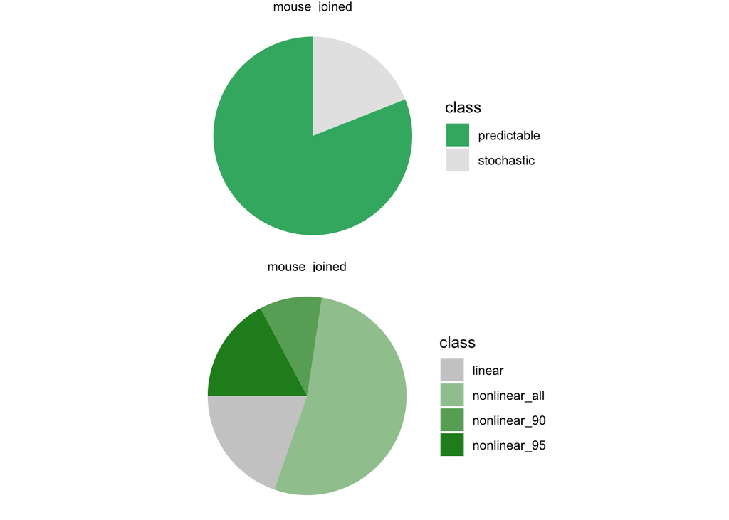

```r
plot_sets <- c("mouse_joined","yeast_wt_full")

df_uEDM_totals <- out_uEDM %>%
  group_by(data_set) %>%
  filter(has_data) %>%
  mutate(predictable = !stochastic) %>%
  mutate(nonlinear_all = nonlinear_all & !nonlinear_90) %>%
  mutate(nonlinear_90 = nonlinear_90 & !nonlinear_95) %>%
  mutate_at(vars(c("linear",starts_with("nonlinear"))), funs((predictable)*(.))) %>%
  summarise_at(vars(c("has_data","stochastic","predictable","linear",starts_with("nonlinear"))),funs( sum(.,na.rm=TRUE))) %>%
  mutate(stat = "total") %>%
  select(data_set,stat,everything())

g_pie1 <- df_uEDM_totals %>%
  filter(data_set %in% plot_sets) %>%
      mutate_at(vars(c("stochastic","predictable")),
               funs( ./has_data ) )%>%
  select(data_set,stochastic,predictable) %>%
  gather(key = "class",value="fraction",stochastic:predictable) %>%
  ggplot(aes(x=factor(1),y=fraction,fill=class)) + geom_bar(width = 1,stat="identity") +
    coord_polar(theta="y") +
    scale_fill_manual(values=c(stochastic="grey90",predictable="mediumseagreen")) +
    theme_void() + facet_wrap(~data_set)

g_pie2 <- df_uEDM_totals %>%
  filter(data_set %in% plot_sets) %>%
  mutate_at(vars(c("linear",starts_with("nonlinear"))), funs(./predictable)) %>%
  select(data_set,linear,starts_with("nonlinear")) %>%
  gather(key = "class",value="fraction",-data_set) %>%
  mutate(class=factor(class,levels=c("linear","nonlinear_all","nonlinear_90","nonlinear_95"))) %>%
  ggplot(aes(x=factor(1),y=fraction,fill=class,alpha=class)) + geom_bar(width = 1,stat="identity") +
    coord_polar(theta="y",star=-pi/2) +
    scale_fill_manual(values=c(linear="grey80",
                               nonlinear_all="forestgreen",
                               nonlinear_90="forestgreen",
                               nonlinear_95="forestgreen")) +
      scale_alpha_manual(values=c(linear=1,
                               nonlinear_all=.5,
                               nonlinear_90=.75,
                               nonlinear_95=1)) +
    theme_void() + facet_wrap(~data_set)

gridExtra::grid.arrange(gridExtra::arrangeGrob(g_pie1),gridExtra::arrangeGrob(g_pie2),nrow=2)
```

## SPECIFIC GENE-GENE ANALYSES YEAST

Most of the figures and results relating to gene-gene interactions in the Main Text focus on the targets of the two experimental manipulations. This next section reproduces these results. First we define variables identifying the two target genes.

```r
ExM1_target <- c(WHI5="YOR083W")
ExM2_target <- c(YHP1="YDR451C")
```

Before performing comprehensive analysis across all possible targets, we reproduce Main Text Figure 3 that shows the specific case of the gene-gene relationship between WHI5 and SWI4. The raw data reveal an absence of linear cross-correlation. However, lack of correlation does not indicate a lack of causation in nonlinear systems. Causation can instead be estimated by looking at ability to cross-map states from one manifold to another. The third panel of Figure 3 involves paired attractors with nearest neighbor time points selected on the SWI4 manifold and cross-identified on the WHI5 manifold.

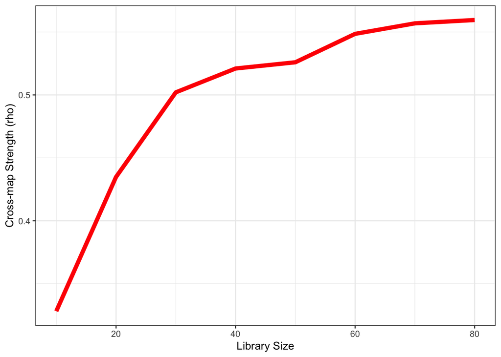

```r
genes <- c(SWI4="YER111C", WHI5="YOR083W")

n1 <- NROW(gene_block_WT1)
n2 <- NROW(gene_block_WT2)

lib_fig3c <- rbind(c(1, n1),
             n1 + c(1, n2))
block_fig3c <- rbind(gene_block_WT1[, genes],
               gene_block_WT2[, genes])

## Calculate full library hindcast cross-map skill (tp=-1) across E=1:8
ccm_tp_1 <- map_df(1:8, function(E) {
    ccm(block_fig3c, lib = lib_fig3c, tp = -1, E = E,
        lib_sizes = n1 + n2, random_libs = FALSE,
        lib_column = genes[1], target_column = genes[2],
        silent = TRUE)
})

## The best E should be E = 5
best_E <- ccm_tp_1$E[which.max(ccm_tp_1$rho)]

## Now perform instanteneous cross-map skill (tp=0) at best_E across library sizes.
SWI4_xmap_WHI5 <- ccm(block_fig3c, lib = lib_fig3c, tp = 0, E = best_E,
                      lib_sizes = seq(10, 80, by = 10),
                      num_samples = 200,
                      lib_column = genes[1], target_column = genes[2],
                      silent = TRUE, RNGseed = 42)

g_SW4_xmap_WHI5 <- ggplot(SWI4_xmap_WHI5,
                  aes(x = lib_size, y = rho)) +
    labs(x = "Library Size", y = "Cross-map Strength (rho)") +
    stat_summary(fun.y = mean, geom = "line", col = "red", size = 2) +
    stat_summary(fun.data = mean_cl_normal, geom = "ribbon", alpha = 0.3) +
    theme_bw()
print(g_SW4_xmap_WHI5)
```

We can repeat CCM analysis across the other WHI5 interactors explored in the early figures of the Main Text. First we write a function to compute the full-library CCM skill between all pairs of genes in a subnetwork.

```r
compute_ccm_on_block <- function( block,
                                lib = c(1,NROW(block)),
                               max_E = 8,
                               results_file = NULL)
{
    genes = names(block)

    params <- expand.grid(from_gene = genes, to_gene = genes) %>%
        filter(from_gene != to_gene)

    ccm_results <- map_df(1:NROW(params), function(i) {
        from_gene <- params$from_gene[i]
        to_gene <- params$to_gene[i]

        ccm_tp_1 <- map_df(1:max_E, function(E) {
            ccm(block, lib = lib, tp = -1, E = E,
                lib_sizes = NROW(block), random_libs = FALSE,
                lib_column = from_gene, target_column = to_gene,
                silent = TRUE)
        })
        best_E <- ccm_tp_1$E[which.max(ccm_tp_1$rho)]

        if(length(best_E) == 1) # compute CCM using tp = 0
        {
            ccm_tp_0 <- ccm(block, lib = lib, tp = 0, E = best_E,
                            lib_sizes = NROW(block), random_libs = FALSE,
                            lib_column = from_gene, target_column = to_gene,
                            silent = TRUE)
        } else { # if invalid, return NA results
            ccm_tp_0 <- data.frame(E = NA, tau = NA, tp = NA,
                                   num_neighbors = NA,
                                   lib_column = from_gene, target_column = to_gene,
                                   lib_size = NA, num_pred = NA,
                                   rho = NA, mae = NA, rmse = NA)
        }

        return(ccm_tp_0)
    })

    if(!is.null(results_file))
    {
        save(ccm_results, file = results_file)
    }
    return(ccm_results)
}
```

We apply this to a four-gene subnetwork around WHI5.

```r
genes_whi5_network <- c("WHI5"="YOR083W",
                        "CLN3"="YAL040C",
                        "SWI4"="YER111C",
                        "CLB2"="YPR119W")

# out_whi5_network_xmap <- compute_ccm_matrix(genes = genes_whi5_network)

  n1 <- NROW(gene_block_WT1)
  n2 <- NROW(gene_block_WT2)

  lib_WT_composite <- rbind(c(1, n1),
                 n1 + c(1, n2))

    block_whi5_network <- rbind(gene_block_WT1[, genes_whi5_network],
                   gene_block_WT2[, genes_whi5_network])

    names(block_whi5_network) <- names(genes_whi5_network)

out_whi5_network_xmap <- compute_ccm_on_block( block_whi5_network,
                                lib = lib_WT_composite,
                               max_E = 8,
                               results_file = NULL)
```

These are then plotted in ggraph. Note that the direction of arrows in the plot correspond to the causal direction, which is reciprocal to the cross-map calculation. That is, if Gene Y cross-maps states of Gene X, this indicates a causal influence of Gene X on Gene Y.

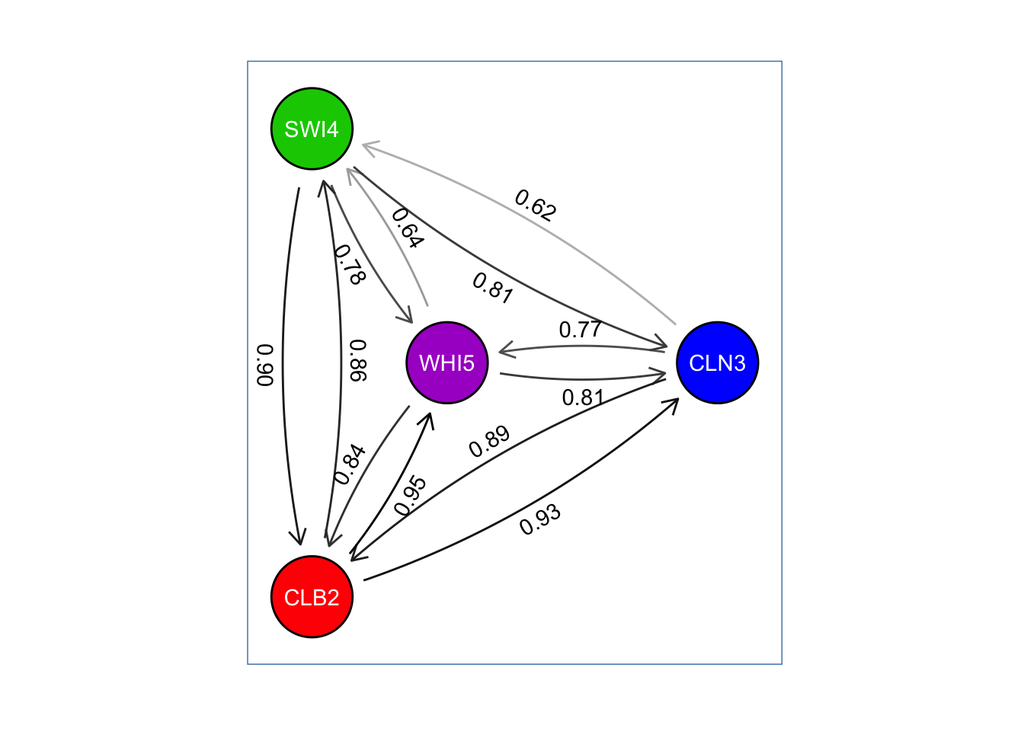

```r
color_key_whi5_network <- list("CLN3" = "#0000FF", # "blue",
                               "SWI4"="#00CC00", # "green",
                               "WHI5"="#AA00CC", # purple",
                               "CLB2"="#FF0000") # "red")

g <- graph_from_data_frame(out_whi5_network_xmap[, c("target_column","lib_column")])
E(g)$weight <- 0.5 + out_whi5_network_xmap$rho/2
E(g)$rho_val <- format(out_whi5_network_xmap$rho, digits = 2)
V(g)$color <- color_key_whi5_network[V(g)$name]

node_size <- 0.15
g_whi5_network <- ggraph(g, layout = "star", center = "WHI5") +
  geom_edge_fan(aes(label = rho_val, colour = weight),
                # geom_edge_fan(aes(label = rho_val, alpha = weight),
                show.legend = FALSE,
                angle_calc = "along",
                label_dodge = unit(-3, "mm"),
                arrow = arrow(length = unit(3, "mm")),
                start_cap = circle(node_size/1.5, "npc"),
                end_cap = circle(node_size/1.5, "snpc")) +
  geom_node_circle(aes(r = node_size, fill = color), show.legend = FALSE) +
  # scale_edge_colour_grey() +
  # lims(edge_colour=c(0,1)) +
  scale_edge_colour_gradient(low="#BBBBBB",high="#000000") +
  geom_node_text(aes(label = name), color = "white") +
  theme_graph(foreground = 'steelblue', fg_text_colour = 'white') +
  coord_fixed()


print(g_whi5_network)
```

```r
# print(my_plot)
#
# pdf("figures/figure_4a.pdf", width = 6, height = 6)
# print(my_plot)
# dev.off()
```

## EXPERIMENTAL VALIDATION ANALYSIS

Proceeding to the comprehensive analysis across all possible interactors with WHI5 and YHP1, we define a function to drop genes from analysis that do not have sufficient data. These are generally genes that have all 0 reads in the raw data.

```r
is_bad_data <- function(ts) (sum(is.finite(ts)) < 2 ||
              var(ts, na.rm = TRUE) < 0.00001 ||
              var(ts[-1], na.rm = TRUE) < 0.00001)

is_bad_data_2 <- function(ts) ( !is.finite(var(ts)) || var(ts) < 0.00001 || var(ts) < 0.00001 )
```

Define the function to compute the pairwise correlation between the manipulated target of a batch (WHI5 or YHP1) and all other targets.

```r
compute_correlation_to_target_gene <- function(gene_block,
                                               target_gene)
{
    target_ts <- gene_block[, target_gene]

    gene_names <- setdiff(names(gene_block), c("dataset", "time"))
    data_block <- gene_block[, gene_names]

    corr_results <- data.frame(gene = gene_names,
                               metric = "corr_rho",
                               value = NA)

    for(i in seq_len(NCOL(data_block)))
    {
        ts <- data_block[, i]
        # if(! (sum(is.finite(ts)) < 2 ||
        #       var(ts, na.rm = TRUE) < 0.00001 ||
        #       var(ts[-1], na.rm = TRUE) < 0.00001))

          if(!is_bad_data(ts))
            corr_results$value[i] <- cor(ts, target_ts, use = "pairwise")
    }
    return(corr_results)
}
```

Next, define the function to compute the pairwise cross-map skill between the manipulated target of a batch (WHI5 or YHP1) and all other targets. We are interested in the casual relationships in wildtype expression, which means we have two realizations to work with, WT1 and WT2. For identifying causal genes, we would like the most accurate cross-map skill measurement from the densist (in terms of observations) possible attractor. As described in the Methods, since WT1 and WT2 should be separate realizations of the same underlying rules, we can concatenate these together to form a composite attractor with twice as many points. However, we are also interested in checking how robust our CCM measurements are. Thus we also run CCM calculations separately for each gene with just WT1 data and just WT2 data. In all cases, we use hindcast cross-map skill (at tp = -1) to select an optimal embedding dimension between 1 and 8, before measuring instanteneous cross-map skill (at tp = 0) at the optimal embedding dimension.

```r
compute_ccm_to_target_gene <- function(gene_block_1,
                                       gene_block_2,
                                       target_gene,
                                       max_E = 8)
{
    gene_block_wt <- rbind(gene_block_1, gene_block_2)
    gene_names <- setdiff(names(gene_block_1), c("dataset", "time"))
    n1 <- NROW(gene_block_1)
    n2 <- NROW(gene_block_2)

    lib <- rbind(c(1, n1),
                 n1 + c(1, n2))
    columns <- lapply(1:max_E, function(E) {
        seq(from = 2, length.out = E)
    })

    ccm_results <- map_df(setdiff(gene_names, target_gene), function(gene) {
        block <- gene_block_wt[, c(target_gene, gene)]
        for(lag in 1:(max_E-1))
        {
            to_lag <- block[, NCOL(block)]
            block[, NCOL(block)+1] <- c(NA, to_lag[1:(n1-1)],
                                        NA, to_lag[n1 + (1:(n2-1))])
        }

        # determine best E
        ccm_tp_1 <- map(1:2,function(i){
          block_lnlp(block, lib = lib[i,], pred = lib[i,], tp = -1,
                               target_column = 1, columns = columns,
                               silent = TRUE)
          })

        best_E <- map(ccm_tp_1, ~which.max(.x$rho))
        # if any best_E elements invalid, return NA results
        if(reduce(map(best_E,~`!=`(length(.x),1)),`|`)){
            return(data.frame(lib_column = gene, target_column = target_gene,
                              rho = NA, mae = NA, rmse = NA,
                              E_1 = NA, rho_1 = NA, mae_1 = NA, rmse_1 = NA,
                              E_2 = NA, rho_2 = NA, mae_2 = NA, rmse_2 = NA))
        }

        ## compute CCM to each WT realization separately
        out <- map(1:2,function(i) {
          block_lnlp(block, lib = lib[i,], pred = lib[i,],tp = 0,
                     target_column = 1, columns = columns[[ best_E[[i]] ]],
                     silent = TRUE,stats_only = FALSE)
          })

        ccm_half <- map(out,~select(.x,-model_output))

        ccm_tp_0 <- invoke(compute_stats,
                           do.call(bind_rows,map(out,~.x$model_output[[1]])) %>%
                             select(obs,pred) %>%
                             rename(observed=obs,predicted=pred))

        return(data.frame(lib_column = gene, target_column = target_gene,
                          rho = ccm_tp_0$rho, mae = ccm_tp_0$mae, rmse = ccm_tp_0$rmse,
                          E_1=best_E[[1]], rho_1 = ccm_half[[1]]$rho,
                          mae_1 = ccm_half[[1]]$mae, rmse_1 = ccm_half[[1]]$rmse,
                          E_2=best_E[[2]], rho_2 = ccm_half[[2]]$rho,
                          mae_2 = ccm_half[[2]]$mae, rmse_2 = ccm_half[[2]]$rmse))
    })

    return(ccm_results)
}
```

Define the function to compute the difference in co-prediction between wildtype and experimentally manipulated dynamics. As described in the Main Text and Methods, to evaluate changes under the experimental manipulation in Batch 1 (wildtype control to experimental manipulation), we use the wildtype dynamics of Batch 2 as a reference, and vice versa. We do a traditional univariate lag-coordinate embedding of the data using separate `lib` and `pred` sets. The `lib` corresponds to the reference attractor, and the `pred` to either the control wildtype or experimental manipulation time series for the target batch. For each we select the maximum simplex projection forecast skill across embedding dimensions between 1 and 8. These two prediction skills are compared to compute `rho_diff`, a measurement of the change in dynamics under the experimental manipulation. The significance of the difference is assessed by two-sample Wilcoxon test on the mean absolute errors of observed and co-predicted values. For comparison, we also compute a simple change in levels by calculating the difference in median expression in the control wildtype and experimental manipulation time series, and assess the significance by a two-sample Wilcoxon test of the expression levels themselves.

```r
compute_copred <- function(gene_block_reference,
                           gene_block_control,
                           gene_block_experiment)
{
  # this function computes co-prediction using cross-batch library and prediction sets.
  n_reference <- NROW(gene_block_reference)
  n_control <- NROW(gene_block_control)
  n_experiment <- NROW(gene_block_experiment)

  lib_reference <- c(1, n_reference)
  lib_control <- c(1,n_control) + n_reference
  lib_experiment <- c(1, n_experiment) + n_reference + n_control

  gene_names <- setdiff(names(gene_block_reference), c("dataset", "time"))

  copred_results <- map_df(gene_names, function(gene) {

    ts <- c(gene_block_reference[,gene],gene_block_control[,gene],gene_block_experiment[,gene])

    # check for bad time series
    if(is_bad_data_2(ts))
      return(data_frame(gene = gene,
                        E = NA,
                        simplex_wt = list(NA),
                        copred_mae_pval = NA,
                        copred_rmse_pval = NA,
                        copred_to_wt = list(NA),
                        copred_to_exp = list(NA)))


    # compute simplex for wildtype to wildtype
    copred_to_wt <- simplex(ts,
                            lib = lib_reference,
                            pred = lib_control,
                            E = 1:8,
                            silent = TRUE,
                            stats_only = FALSE) %>%
      filter(rank(-rho, ties.method="first")==1)

    # compute simplex for wildtype to mutant
    copred_to_exp <- simplex(ts,
                             lib = lib_reference,
                             pred = lib_experiment,
                             E = 1:8,
                             stats_only = FALSE) %>%
      filter(rank(-rho, ties.method="first")==1)

    copred_mae_pval <- wilcox.test(
      abs(copred_to_wt$model_output[[1]]$pred - copred_to_wt$model_output[[1]]$obs),
      abs(copred_to_exp$model_output[[1]]$pred - copred_to_exp$model_output[[1]]$obs),
      alternative="less"
    )$p.value

    # copred_rmse_pval <- wilcox.test(
    #   (copred_to_wt$model_output[[1]]$pred - copred_to_wt$model_output[[1]]$obs)^2,
    #   (copred_to_exp$model_output[[1]]$pred - copred_to_exp$model_output[[1]]$obs)^2,
    #   alternative="less"
    # )$p.value

    lib2index <- function(lib) unlist(apply(as.matrix(lib),2,function(x) seq(x[1],x[2])))

    distr_change <- wilcox.test(x = ts[lib2index(lib_control)],
                                y = ts[lib2index(lib_experiment)],
                                paired = FALSE, conf.int = TRUE)
    # dmedian <- distr_change$estimate
    dmedian <- median(ts[lib2index(lib_control)])-median(ts[lib2index(lib_experiment)])
    dmedian_pval <- distr_change$p.value

    return(data_frame(gene = gene, E = copred_to_exp$E[1],
                      simplex_wt = NA,
                      copred_mae_pval,
                      # copred_rmse_pval,
                      copred_to_wt = list(copred_to_wt),
                      copred_to_exp = list(copred_to_exp),
                      dmedian = dmedian,
                      dmedian_pval = dmedian_pval))
  })

  return(copred_results)
}
```

The final function definitions for the gene-gene analysis are to aggregate results of the correlation, cross-map, and co-prediction analyses and bin for comparison between high-CCM-low-corr and low-CCM-low-corr genes as in Main Text Figure 5.

```r
aggregate_results <- function(corr_results,
                              ccm_results,
                              copred_results)
{
  ccm_output <- data.frame(gene = as.character(ccm_results$lib_column),
                           ccm_results[, c("rho", "mae", "rmse")]) %>%
    tidyr::gather(metric, value, rho:rmse)
  ccm_output$metric <- paste0("ccm_", ccm_output$metric)

  output <- bind_rows(ccm_output, corr_results)
  output <- tidyr::spread(output, metric, value)

  copred_output <- copred_results %>%
    filter(is.finite(.$E)) %>%
    mutate(copred_rho_diff = map_dbl(copred_to_wt, ~.x$rho) -
             map_dbl(copred_to_exp, ~.x$rho),
           copred_rho_max =  pmax(map_dbl(copred_to_wt, ~.x$rho),
                                  map_dbl(copred_to_exp, ~.x$rho)),
           copred_rho_min = pmin(map_dbl(copred_to_wt, ~.x$rho),
                                 map_dbl(copred_to_exp, ~.x$rho)),
           simplex_rho = NA,
           copred_rho_wt = map_dbl(copred_to_wt, ~.x$rho),
           copred_rho_exp = map_dbl(copred_to_exp, ~.x$rho)) %>%
    select(-copred_to_wt,-copred_to_exp,-simplex_wt)

  output <- full_join(output,copred_output,by='gene')

  return(output)
}

bin_copred_topbot <- function(output,
                              thresh_corr=0.1,
                              min_copred_thresh=0.1,
                              max_copred_thresh = min_copred_thresh,
                              thresh_ccm_high = NULL,
                              thresh_ccm_low = NULL,
                              n_compare=100)
{
  output %>%
    select_if(~sum(!is.na(.)) > 0) %>%
    ungroup() %>%
    filter(complete.cases(.)) %>%
    filter(abs(corr_rho) <= thresh_corr) %>%
    filter( copred_rho_min > min_copred_thresh) %>%
    filter( copred_rho_max > max_copred_thresh) %>%
    mutate(bins=cut(rank(ccm_rho),
                    breaks=c(0,n_compare,n()-n_compare,n()))) %>%
    mutate(bins=factor(bins,labels=c("low_ccm","mid_ccm","high_ccm"))) %>%
    filter(as.numeric(bins) != 2)
}
```

We apply these three analyses with WHI5 as the target gene (the manipulated gene of Batch 1), saving the results for further analysis.

```r
out_file <-  "./output/whi5_TPM_analysis.RData"
out_file_aggregate <- "output/whi5_TPM_deviation_calcs.Rdata"

if(!file.exists(out_file)){
  load("data/gene_blocks_TPM_corrected.Rdata")

  target_gene <- ExM1_target

  corr_results <- compute_correlation_to_target_gene(rbind(gene_block_WT1,
                                                           gene_block_WT2),
                                                     target_gene)

  ccm_results <- compute_ccm_to_target_gene(gene_block_WT1,
                                            gene_block_WT2,
                                            target_gene)

  copred_results <- compute_copred(gene_block_reference=gene_block_WT2,
                                   gene_block_control=gene_block_WT1,
                                   gene_block_experiment=gene_block_ExM1)

  save(corr_results, ccm_results, copred_results, file = out_file)
}

if(!file.exists(out_file_aggregate)){
  load(out_file)
  output <- aggregate_results(corr_results,
                              ccm_results,
                              copred_results)

  output_binned <- bin_copred_topbot(output,
                                   thresh_corr = 0.1,
                                   min_copred_thresh = -1)

  save(output, output_binned, file = out_file_aggregate)
}

exp1 <- new.env()
load("output/whi5_TPM_deviation_calcs.Rdata",envir = exp1)
```

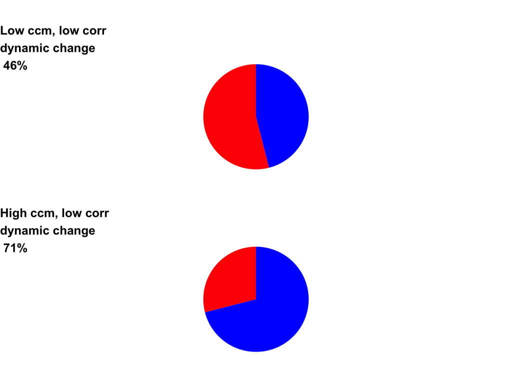

```r
plot_pie_charts(exp1$output_binned)
```

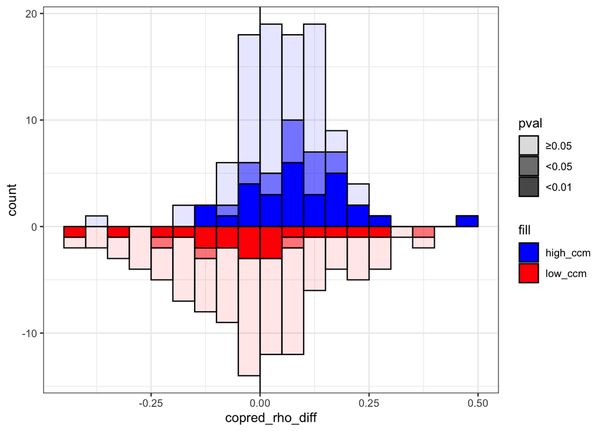

```r
plot_copred_top_bottom_pval(exp1$output_binned,
                       x_var = "copred_rho_diff")
```

We can also compute a significance for this comparison, again using two-sample Wilcoxon test as the distributions have no reason to conform to something parametric.

```r
wilcox.test(exp1$output_binned$copred_rho_diff[exp1$output_binned$bins=="low_ccm"],exp1$output_binned$copred_rho_diff[exp1$output_binned$bins=="high_ccm"],paired = FALSE)
```

```
##
##  Wilcoxon rank sum test with continuity correction
##
## data:  exp1$output_binned$copred_rho_diff[exp1$output_binned$bins ==  and exp1$output_binned$copred_rho_diff[exp1$output_binned$bins ==     "low_ccm"] and     "high_ccm"]
## W = 3510, p-value = 0.0002732
## alternative hypothesis: true location shift is not equal to 0
```

And we also apply the three analyses with YHP1 as the target gene.

```r
out_file <-  "./output/yhp1_TPM_analysis.RData"
out_file_aggregate <- "output/yhp1_TPM_deviation_calcs.Rdata"

if(!file.exists(out_file)){
  load("data/gene_blocks_TPM_corrected.Rdata")

  target_gene <- ExM2_target

  corr_results <- compute_correlation_to_target_gene(rbind(gene_block_WT1,
                                                           gene_block_WT2),
                                                     target_gene)

  ccm_results <- compute_ccm_to_target_gene(gene_block_WT1,
                                            gene_block_WT2,
                                            target_gene)

  copred_results <- compute_copred(gene_block_ref=gene_block_WT1,
                                   gene_block_control=gene_block_WT2,
                                   gene_block_experiment=gene_block_ExM2)

  save(corr_results, ccm_results, copred_results, file = out_file)
}

if(!file.exists(out_file_aggregate)){
  load(out_file)
  output <- aggregate_results(corr_results,
                              ccm_results,
                              copred_results)

  output_binned <- bin_copred_topbot(output,
                                   thresh_corr = 0.1,
                                   min_copred_thresh = -1)

  save(output, output_binned, file = out_file_aggregate)
}

exp2 <- new.env()
load("output/yhp1_TPM_deviation_calcs.Rdata",envir = exp2)
```

After binning the 100 high CCM low corr and 100 low CCM low corr, we we reproduce the pie and bar charts of Main Text Figure 5.

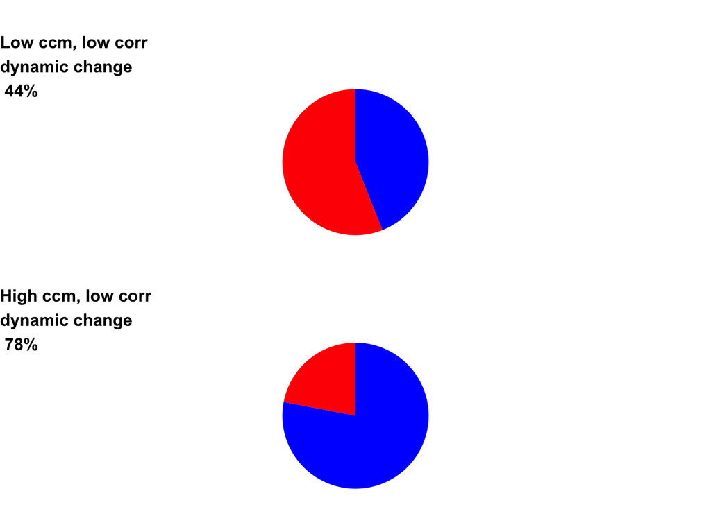

```r
plot_pie_charts(exp2$output_binned)
```

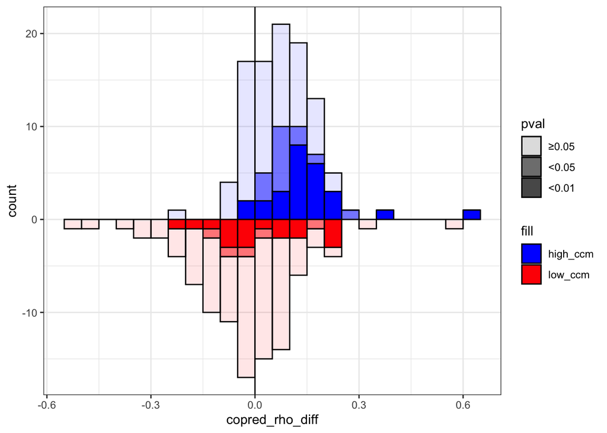

```r
plot_copred_top_bottom_pval(exp2$output_binned,
                       x_var = "copred_rho_diff")
```

As with WHI5, we also compute a significance for this comparison using two-sample Wilcoxon test.

```r
wilcox.test(exp2$output_binned$copred_rho_diff[exp2$output_binned$bins=="low_ccm"],exp2$output_binned$copred_rho_diff[exp2$output_binned$bins=="high_ccm"],paired = FALSE)
```

```
##
##  Wilcoxon rank sum test with continuity correction
##
## data:  exp2$output_binned$copred_rho_diff[exp2$output_binned$bins ==  and exp2$output_binned$copred_rho_diff[exp2$output_binned$bins ==     "low_ccm"] and     "high_ccm"]
## W = 2724, p-value = 2.698e-08
## alternative hypothesis: true location shift is not equal to 0
```

## MOUSE GENE NETWORK

```r
genes_IkBa_network <- c(IkBa="MUSG021025.7",
                 cJun="MUSG052684.4",
                 RelA="MUSG024927.7",
                 CDKN1A="MUSG023067.10")
```

```r
block_IkBa <- gene_block_mouse_joined[,genes_IkBa_network]
names(block_IkBa) <- names(genes_IkBa_network)

lib_IkBa <- c(1,69)

out_IkBa_network_xmap <- compute_ccm_on_block(block_IkBa,lib=lib_IkBa,max_E = 6) %>%
  select(target_column,lib_column,rho) %>%
  # filter(rho > .4) %>%
  mutate_at(vars(ends_with("column")),as.character) %>%
  arrange(lib_column,target_column)
```

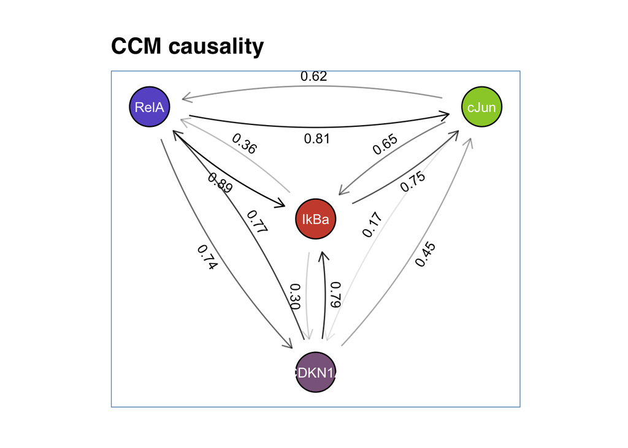

```r
color_key_IkBa_network <- list("IkBa" = "tomato3",
                               # "ACTB" = "orangered",
                               "cJun" = "yellowgreen",
                               "RelA" = "slateblue",
                               "CDKN1A" = "plum4")

layout_key_IkBa_network <- list("IkBa" = c(1.25,2/sqrt(3)),
                                "RelA" = c(0,2),
                                "cJun" = c(2.5,2),
                                "CDKN1A" = c(1.25,0))

g_IkBa_network <- plot_net_from_rho(out_IkBa_network_xmap,color_key_IkBa_network,layout_key_IkBa_network)

print(g_IkBa_network + ggtitle("CCM causality") + theme(plot.title=element_text(family="sans")))
```